# Clustering and classification

Mark Dunning; mark ‘dot’ dunning ‘at’ cruk.cam.ac.uk, Oscar Rueda; oscar ‘dot’ rueda ‘at’ cruk.cam.ac.uk

Last modified: 03 Feb 2017

[output not shown]

# Description

The tutorial covers the application of a number of exploratory analysis techniques to real-life microarray experiments

- Clustering
  - and making a heatmap
- Principal Components Analysis
- Classification

# Data Pre-processing

We will re-use the colon cancer data in GSE33126, and saw yesterday how to import these data into R.

```r
library(GEOquery)
url <- "ftp://ftp.ncbi.nih.gov/pub/geo/DATA/SeriesMatrix/GSE33126/"
filenm <- "data/GSE33126_series_matrix.txt.gz"
if(!file.exists(filenm)) download.file(paste(url, filenm, sep=""), destfile=filenm)
colonData <- getGEO(filename=filenm)
```

```
not all columns named in 'colClasses' exist
```

```r
colonData
```

```
ExpressionSet (storageMode: lockedEnvironment)
assayData: 48803 features, 18 samples
  element names: exprs
protocolData: none
phenoData
  sampleNames: GSM820516 GSM820517 ... GSM820533 (18 total)
  varLabels: title geo_accession ... data_row_count (31 total)
  varMetadata: labelDescription
featureData
  featureNames: ILMN_1343291 ILMN_1343295 ... ILMN_2416019 (48803 total)
  fvarLabels: ID nuID ... GB_ACC (30 total)
  fvarMetadata: Column Description labelDescription
experimentData: use 'experimentData(object)'
Annotation: GPL6947
```

We will log$_2$ transform the expression data

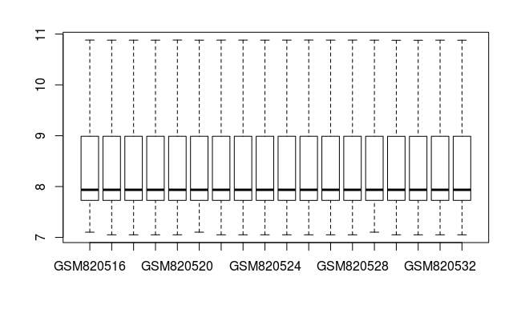

```r
exprs (colonData) <- log2 (exprs(colonData))
boxplot(exprs(colonData),outline=FALSE)
```

## Filtering the data

A first step in the analysis of microarray data is often to remove any uniformative probes. We can do this because typically only 50% of probes genes will be expressed, and even fewer than this will be differentially expressed. Including such non-informative genes in visualisa- tion will obscure any biological differences that exist. As we saw yesterday, the `genefilter` package contains a suite of tools for the filtering of microarray data. The `varFilter` function allows probes with low- variance to be removed from the dataset. The metric using to decide which probes to remove is the Inter-Quartile Range (IQR), and by default half of the probes are removed. Both the function used to do the filtering, and cut-off can be specified by the user.

```r
library (genefilter)
dim (colonData)
```

```
Features  Samples
   48803       18
```

```r
varFiltered <- varFilter (colonData)
dim (varFiltered)
```

```
Features  Samples
   24401       18
```

```r
nrow (colonData) / nrow (varFiltered)
```

```
Features
2.000041
```

## Clustering.. or Classification?

- **Unsupervised:** classes unknown, want to discover them from the data (cluster analysis)
- **Supervised:** classes are predefined, want to use a (training or learning) set of labelled objects to form a classifier for classification of future observations

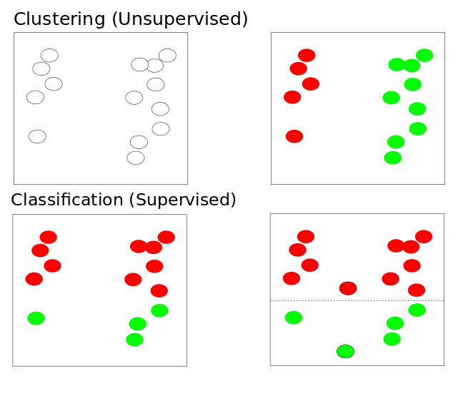

# Clustering

## Why do clustering for genomic data?

- Clustering leads to readily interpretable figures and can be helpful for identifying patterns in time or space.
- We can cluster samples (columns)
  - e.g. identification of new / unknown tumor classes using gene expression profiles
- We can cluster genes (rows)
  - e.g. using large numbers of yeast experiments to identify groups of co-regulated genes
  - we can cluster genes to reduce redundancy (i.e. variable selection) in predictive models

### Subtype Discovery

- There are plenty of examples of using clustering to discover subtypes in the literature

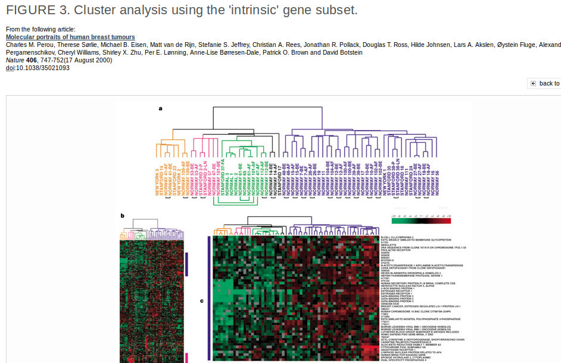

### Clustering as QA

- Also used as a quality assessment tool
  - to check for outlier samples

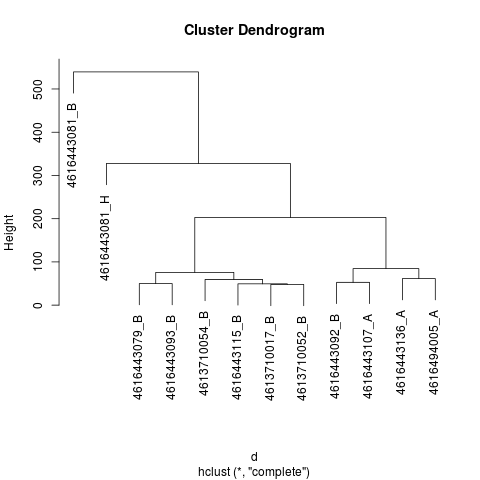

- Can check within / between experiment variability and potential confounding factors (batch effect etc)

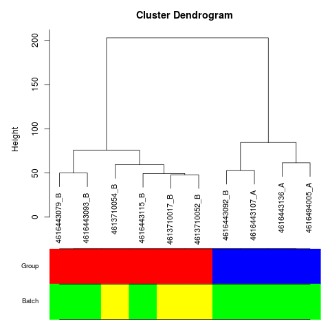

### Clustering Overview

- Steps in a Cluster Analysis
  1. Preprocess the data
  2. Choose a *dissimilarity* measure
  3. Choose a cluster algorithm
  4. Select the number of clusters
  5. Validate the procedure

When clustering genes, it is common to pre-process;

- normalise
- filter; remove genes with low variability across samples and many missing values
- (possibly impute missing values)
- standardise; e.g. zero-mean and, unit variance:
  - $y_g^* = (y_g - \mu_g)/\sigma_g$
  - subtracting the mean expression level and divide by standard deviation
  - the algorithm may already do this

### How to compute similarity

Common *Similarity* / *Dissimilarity* measures include

- Correlation coefficient; *scale invariant*
  - Pearson’s correlation;
  - Spearman correlation of ranks
- Distance: scale dependant
  - Euclidean distance; $d(x,y) = \sqrt{\sum_i (x_i - y_i)^2}$
  - City block (Manhattan) distance; $d(x,y) = \sum | x_i - y_i |$
  - and others…..
- *Warning*: Don’t get too hung-up on the choice of measure
  - Clustering is primarily an exploratory tool
  - If your data has signal, it should show regardless of which measure you choose
  - Don’t just pick the one which “looks the best”

### How to compute similarity, in R

The `dist` function can be used to calculate a variety of similarity measures

- As usual, we can do `?dist`.
- The input is a matrix of numerical values
- Let’s test with some sample data
  - we use `set.seed` here to make sure we always get the same values

```r
set.seed(10032016)
myMatrix <- matrix(rnorm(1000),ncol=10)
colnames(myMatrix) <- LETTERS[1:10]
head(myMatrix)
```

```
              A          B          C          D          E          F          G          H          I          J
[1,]  0.4313777 -2.4670200 -0.7073725  0.3194366  0.8602843 -0.7072524 -0.6794123 -1.6310056  0.4481794 -1.2323060
[2,] -0.1119854  0.2155933  1.3840235 -2.1342261  0.4873031 -1.4214807  0.8233594  1.1139286 -0.8939646  1.2021941
[3,] -0.8989685  0.4339697  1.5643489 -0.1795468  0.1206374  0.8601242  0.3049781 -0.1753819  1.5622296 -0.5362093
[4,]  0.6369946 -0.9573872  0.1323738 -0.3081852  1.0382901 -0.8216086 -1.9204444 -1.5448343  0.4831130 -0.9426206
[5,]  0.1357330  0.2440095  1.1538843 -1.0067510 -1.3158878 -0.2761261 -0.5078418 -2.5823836  0.4086202 -2.2609447
[6,]  0.6717109 -1.4595497 -0.2515446 -1.5297978  1.1495169  1.6037638 -0.6668203  1.2564544  2.1929750 -0.7531744
```

- The default is to compute distances from the *rows* of the matrix
  - i.e. which would normally be the genes we are measuring

```r
d <- dist(myMatrix)
d
```

[output not shown]

- The more common use of clustering is to cluster the columns (*samples*)
- To do this, we have to *transpose* the matrix; using the function `t`
- Note that the matrix has some values that appear to be missing
  - why do you think that might be?

```r
d <- dist(t(myMatrix))
d
```

```
         A        B        C        D        E        F        G        H        I
B 14.08415
C 14.88023 15.01007
D 15.07597 13.81700 13.92782
E 15.30797 15.18065 12.91680 14.36210
F 13.92214 15.01753 14.35741 12.90844 14.22044
G 16.78331 15.87847 14.93457 14.26315 13.65642 14.24959
H 15.18897 14.91864 13.59910 13.75474 13.14450 13.81787 14.26011
I 15.21106 15.15853 13.90017 13.34724 14.63817 12.75963 16.45115 13.91325
J 16.24253 14.95350 14.28564 14.37443 14.50068 15.69133 14.79427 14.30121 15.45298
```

- Changing the type of distance measure can be done by changing the `method` argument
  - as always, check the help page for full list of options `?dist`

```r
d.man <- dist(t(myMatrix),method="manhattan")
d.man
```

```
         A        B        C        D        E        F        G        H        I
B 115.2690
C 122.7021 121.9089
D 122.9448 113.7223 109.2488
E 121.8248 116.7150 104.0412 117.9643
F 111.4721 121.4489 118.7915 105.4497 116.4869
G 133.4619 132.4103 120.1602 110.9659 108.6304 109.9150
H 122.5602 114.8863 110.4001 106.7878 105.2342 114.3228 114.1843
I 122.4814 121.2553 114.1197 101.7003 117.7069 101.9944 131.5409 111.6427
J 131.3290 123.4407 115.3894 114.4036 122.6288 122.0493 122.2218 117.2269 125.1519
```

### How to calculate correlation in R

- This time we use the `cor` function to calculate correlation(`?cor`)
- What type of correlation is this computing?
  - use the help page to find out
- What do you notice about the output, compared to that of `dist`?

```r
cor(myMatrix)
```

```
            A             B            C           D           E             F           G            H           I           J
A  1.00000000  0.1873257371 -0.023000453 -0.08803428 -0.13080526  0.1055754466 -0.18307097 -0.121188905 -0.01338224 -0.14899699
B  0.18732574  1.0000000000 -0.011511807  0.10968627 -0.08226229  0.0004291339 -0.04082896 -0.046354867  0.01698868  0.05761546
C -0.02300045 -0.0115118072  1.000000000 -0.03532202  0.10502192 -0.0409040361 -0.03337509  0.004657798  0.06663211  0.02827576
D -0.08803428  0.1096862726 -0.035322018  1.00000000 -0.16237803  0.1328635922  0.01087487 -0.064794815  0.10070537 -0.02098191
E -0.13080526 -0.0822622909  0.105021917 -0.16237803  1.00000000 -0.0677951324  0.09412331  0.021381549 -0.08673286 -0.04670010
F  0.10557545  0.0004291339 -0.040904036  0.13286359 -0.06779513  1.0000000000  0.08674360 -0.018787424  0.22943055 -0.16930951
G -0.18307097 -0.0408289615 -0.033375088  0.01087487  0.09412331  0.0867435951  1.00000000  0.015941398 -0.19833124  0.05636269
H -0.12118891 -0.0463548665  0.004657798 -0.06479482  0.02138155 -0.0187874244  0.01594140  1.000000000  0.01838101 -0.02447738
I -0.01338224  0.0169886817  0.066632105  0.10070537 -0.08673286  0.2294305467 -0.19833124  0.018381014  1.00000000 -0.07764364
J -0.14899699  0.0576154555  0.028275765 -0.02098191 -0.04670010 -0.1693095113  0.05636269 -0.024477377 -0.07764364  1.00000000
```

- Clustering algorithms will expect input in distance matrix form
- We can convert using `as.dist`
  - recall that various `as.` functions exist to convert between various types of data. e.g. `as.numeric`, `as.character` etc

```r
corMat <- as.dist(cor(myMatrix))
corMat
```

```
              A             B             C             D             E             F             G             H             I
B  0.1873257371
C -0.0230004526 -0.0115118072
D -0.0880342757  0.1096862726 -0.0353220181
E -0.1308052649 -0.0822622909  0.1050219171 -0.1623780286
F  0.1055754466  0.0004291339 -0.0409040361  0.1328635922 -0.0677951324
G -0.1830709748 -0.0408289615 -0.0333750883  0.0108748704  0.0941233070  0.0867435951
H -0.1211889054 -0.0463548665  0.0046577978 -0.0647948150  0.0213815490 -0.0187874244  0.0159413977
I -0.0133822445  0.0169886817  0.0666321053  0.1007053715 -0.0867328634  0.2294305467 -0.1983312437  0.0183810136
J -0.1489969940  0.0576154555  0.0282757647 -0.0209819071 -0.0467000977 -0.1693095113  0.0563626950 -0.0244773771 -0.0776436408
```

- Two samples with a *higher correlation* values means *more similar*
- …so the *distance* between is *less*
  - `abs` will calculate the absolute value

```r
corMat <- as.dist(1-abs(cor(myMatrix)))
corMat
```

```
          A         B         C         D         E         F         G         H         I
B 0.8126743
C 0.9769995 0.9884882
D 0.9119657 0.8903137 0.9646780
E 0.8691947 0.9177377 0.8949781 0.8376220
F 0.8944246 0.9995709 0.9590960 0.8671364 0.9322049
G 0.8169290 0.9591710 0.9666249 0.9891251 0.9058767 0.9132564
H 0.8788111 0.9536451 0.9953422 0.9352052 0.9786185 0.9812126 0.9840586
I 0.9866178 0.9830113 0.9333679 0.8992946 0.9132671 0.7705695 0.8016688 0.9816190
J 0.8510030 0.9423845 0.9717242 0.9790181 0.9532999 0.8306905 0.9436373 0.9755226 0.9223564
```

### Correlation versus Distance

- The main choice is whether to use a distance-based metric (e.g. Euclidean) or correlation
- A simple toy example of three genes
  - which genes seem to be closest?

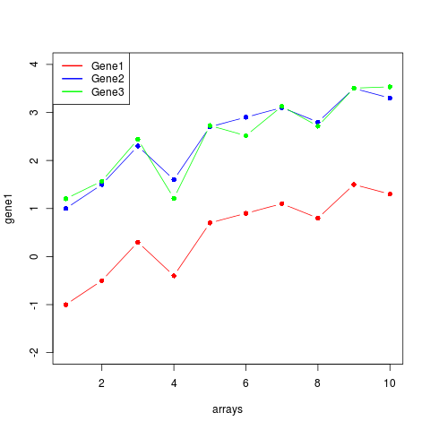

## Calculating a distance matrix for gene expression data

When clustering samples, each entry in the distance matrix should be the pairwise distance between two samples. As the `ExpressionSet` object has genes in the rows, and samples in the column we have to transpose the expression matrix.

**N.B. to calculate the distances between samples, we have to transpose the expression matrix (e.g. using the function `t`). If we do not do this, R will try and compute distances between all genes which may take a long time or exceed the available memory)**

```r
euc.dist <- dist (t(exprs(varFiltered)))
euc.dist
```

```
          GSM820516 GSM820517 GSM820518 GSM820519 GSM820520 GSM820521 GSM820522 GSM820523 GSM820524 GSM820525 GSM820526 GSM820527 GSM820528 GSM820529
GSM820517 146.35076
GSM820518 112.10192 145.53738
GSM820519 127.02787 111.88327 128.89085
GSM820520 103.88617 145.88415  93.26812 124.41043
GSM820521 115.74149 109.59666 112.44568  77.60015 110.62329
GSM820522  86.59678 140.12151 115.68936 131.12234  98.96944 117.26705
GSM820523 118.07552 115.02450 139.86229 101.32561 134.43368  89.05971 105.62731
GSM820524 113.05465 135.64296 106.83091 126.25701  85.61877 117.19595  85.85654 116.10403
GSM820525 142.82777  72.50357 145.43070 101.26515 138.18094 107.93645 127.62848  99.13618 120.46802
GSM820526  87.68842 160.67923 109.56682 126.28151 102.83077 114.59309 107.40340 134.03152 114.20701 154.74502
GSM820527 102.51958 121.92622 119.62366  78.01042 110.89035  69.13310 106.32390  77.38321 115.56748 109.20371 104.05182
GSM820528  85.71746 132.44295  96.04791 115.36869  75.14097 103.00987  89.80380 112.44894  90.45972 124.46834  97.24261  90.59615
GSM820529 107.07671 118.90261 120.08406  94.25470 114.46866  79.01849 116.33941  83.80927 123.55735 107.46869 119.74686  59.39630  86.75871
GSM820530  80.36987 151.46130  94.29680 123.97811  86.59315 103.45768  97.19378 126.82149 107.83406 146.18764  87.43164 101.35185  81.22235 103.68352
GSM820531 108.26678 100.31635 115.03569  82.27479 112.72244  64.87145 116.26826  91.51850 122.61883 103.07141 119.87820  70.55040  96.07646  70.24274
GSM820532 128.93571  95.33138 115.04522 106.11806 116.81059 102.43630 124.92807 122.94258 116.57744 103.39879 137.24907 113.49486 105.14902 109.33036
GSM820533 106.21944 134.12719 115.78666  97.39843 115.37280  68.75089 116.89886  93.17867 127.75562 130.21971 109.87582  64.16850  99.91990  68.56935
          GSM820530 GSM820531 GSM820532
GSM820517
GSM820518
GSM820519
GSM820520
GSM820521
GSM820522
GSM820523
GSM820524
GSM820525
GSM820526
GSM820527
GSM820528
GSM820529
GSM820530
GSM820531  99.39146
GSM820532 120.61473  93.09175
GSM820533  96.27636  73.49531 119.19071
```

For gene-expression data, it is common to use correlation as a distance metric rather than the Euclidean. As we saw above, the `cor` function can be used to calculate the correlation of columns in a matrix. Each row (or column) in the resulting matrix is the correlation of that sample with all other samples in the dataset. The matrix is symmetrical and we can transform this into a distance matrix by first subtracting 1 from the correlation matrix. Hence, samples with a higher correlation have a smaller ‘distance’.

```r
corMat <- cor(exprs(varFiltered))
corMat
```

```
          GSM820516 GSM820517 GSM820518 GSM820519 GSM820520 GSM820521 GSM820522 GSM820523 GSM820524 GSM820525 GSM820526 GSM820527 GSM820528 GSM820529
GSM820516 1.0000000 0.8582704 0.9171976 0.8937222 0.9286023 0.9112575 0.9503610 0.9081569 0.9156037 0.8648318 0.9493074 0.9302064 0.9511778 0.9241083
GSM820517 0.8582704 1.0000000 0.8600812 0.9173538 0.8588151 0.9202012 0.8696543 0.9126298 0.8781899 0.9650722 0.8293478 0.9009531 0.8829546 0.9061505
GSM820518 0.9171976 0.8600812 1.0000000 0.8907537 0.9425576 0.9163944 0.9115547 0.8713382 0.9247661 0.8601046 0.9209805 0.9051381 0.9388145 0.9047172
GSM820519 0.8937222 0.9173538 0.8907537 1.0000000 0.8978211 0.9602207 0.8864231 0.9324985 0.8949583 0.9322218 0.8950744 0.9597308 0.9117054 0.9413361
GSM820520 0.9286023 0.8588151 0.9425576 0.8978211 1.0000000 0.9187180 0.9349881 0.8806670 0.9514800 0.8731558 0.9301280 0.9180982 0.9623691 0.9130390
GSM820521 0.9112575 0.9202012 0.9163944 0.9602207 0.9187180 1.0000000 0.9085925 0.9475820 0.9089643 0.9224893 0.9131154 0.9681213 0.9291090 0.9584997
GSM820522 0.9503610 0.8696543 0.9115547 0.8864231 0.9349881 0.9085925 1.0000000 0.9262929 0.9511794 0.8917089 0.9237271 0.9246435 0.9461775 0.9101066
GSM820523 0.9081569 0.9126298 0.8713382 0.9324985 0.8806670 0.9475820 0.9262929 1.0000000 0.9111565 0.9350314 0.8817770 0.9603706 0.9161095 0.9536168
GSM820524 0.9156037 0.8781899 0.9247661 0.8949583 0.9514800 0.9089643 0.9511794 0.9111565 1.0000000 0.9037952 0.9139681 0.9112436 0.9455812 0.8988913
GSM820525 0.8648318 0.9650722 0.8601046 0.9322218 0.8731558 0.9224893 0.8917089 0.9350314 0.9037952 1.0000000 0.8415122 0.9204252 0.8964670 0.9232237
GSM820526 0.9493074 0.8293478 0.9209805 0.8950744 0.9301280 0.9131154 0.9237271 0.8817770 0.9139681 0.8415122 1.0000000 0.9282016 0.9372344 0.9051941
GSM820527 0.9302064 0.9009531 0.9051381 0.9597308 0.9180982 0.9681213 0.9246435 0.9603706 0.9112436 0.9204252 0.9282016 1.0000000 0.9449786 0.9764954
GSM820528 0.9511778 0.8829546 0.9388145 0.9117054 0.9623691 0.9291090 0.9461775 0.9161095 0.9455812 0.8964670 0.9372344 0.9449786 1.0000000 0.9497681
GSM820529 0.9241083 0.9061505 0.9047172 0.9413361 0.9130390 0.9584997 0.9101066 0.9536168 0.8988913 0.9232237 0.9051941 0.9764954 0.9497681 1.0000000
GSM820530 0.9573796 0.8482370 0.9414236 0.8987844 0.9504108 0.9291209 0.9374851 0.8940675 0.9232363 0.8584350 0.9496136 0.9318156 0.9561975 0.9288649
GSM820531 0.9223823 0.9331725 0.9125297 0.9552921 0.9156400 0.9720189 0.9101826 0.9446634 0.9003839 0.9293514 0.9049499 0.9668194 0.9383683 0.9672203
GSM820532 0.8897132 0.9395367 0.9123688 0.9254827 0.9092395 0.9300936 0.8961047 0.8999407 0.9097986 0.9287621 0.8751776 0.9139221 0.9260060 0.9204350
GSM820533 0.9255052 0.8809038 0.9116292 0.9374967 0.9118986 0.9686817 0.9094910 0.9427849 0.8921813 0.8875923 0.9203758 0.9726729 0.9335861 0.9688689
          GSM820530 GSM820531 GSM820532 GSM820533
GSM820516 0.9573796 0.9223823 0.8897132 0.9255052
GSM820517 0.8482370 0.9331725 0.9395367 0.8809038
GSM820518 0.9414236 0.9125297 0.9123688 0.9116292
GSM820519 0.8987844 0.9552921 0.9254827 0.9374967
GSM820520 0.9504108 0.9156400 0.9092395 0.9118986
GSM820521 0.9291209 0.9720189 0.9300936 0.9686817
GSM820522 0.9374851 0.9101826 0.8961047 0.9094910
GSM820523 0.8940675 0.9446634 0.8999407 0.9427849
GSM820524 0.9232363 0.9003839 0.9097986 0.8921813
GSM820525 0.8584350 0.9293514 0.9287621 0.8875923
GSM820526 0.9496136 0.9049499 0.8751776 0.9203758
GSM820527 0.9318156 0.9668194 0.9139221 0.9726729
GSM820528 0.9561975 0.9383683 0.9260060 0.9335861
GSM820529 0.9288649 0.9672203 0.9204350 0.9688689
GSM820530 1.0000000 0.9346090 0.9035232 0.9388144
GSM820531 0.9346090 1.0000000 0.9422943 0.9642204
GSM820532 0.9035232 0.9422943 1.0000000 0.9057118
GSM820533 0.9388144 0.9642204 0.9057118 1.0000000
```

```r
cor.dist <- as.dist(1 - corMat)
```

The values given by the `cor` function can be either positive or negative, depending on whether two samples are positively or negatively correlated. However, for our distance matrix to contain only values in the range 0 to 1. In which case we would need to use the *absolute* values from the correlation matrix before converting to distances.

```r
cor.dist <- as.dist(1 - abs(corMat))
```

We are now ready to use a clustering method.

## Hierachical methods for clustering

- start with *n* samples (or $p$ gene) clusters
- At each step, *merge* the two closest clusters using a measure of *between-cluster* dissimilarity which reflects the shape of the clusters
- The distance between the clusters is defined by the method used (e.g. in *complete linkage*, the distance is defined as the distance between the furthest pair of points in the two clusters)

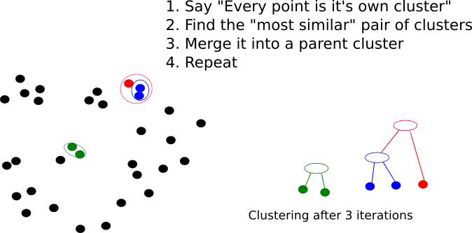

- We also have some control over the definition of distance used when creating a new cluster
  - this will alter the *shape* of the dendrogram
  - some methods will give more compact clusters

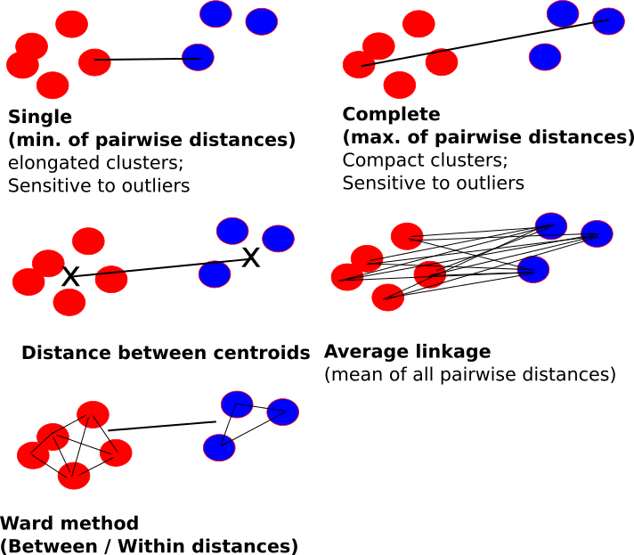

- Dendrograms are good visual guides, but *arbitrary*
- Nodes can be reordered
  - Closer on dendrogram $\ne$ more similar

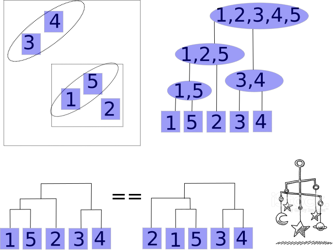

### Performing hierachical clustering, in R

- The function to use here is `hclust` (`?hclust`)
- It takes a distance matrix that you computed previously

```r
clust <- hclust(d)
clust
```

```
Call:
hclust(d = d)

Cluster method   : complete
Distance         : euclidean
Number of objects: 10
```

- The standard plotting function has been extended to visualise the result of the clustering

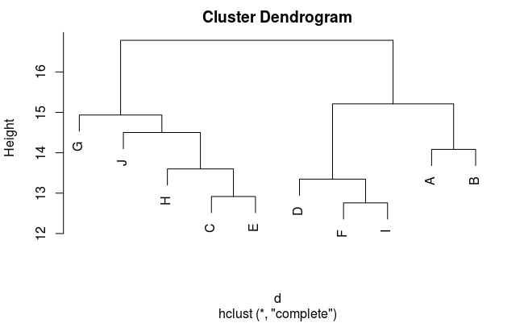

```r
plot(clust)
```

- We can change the name of the method

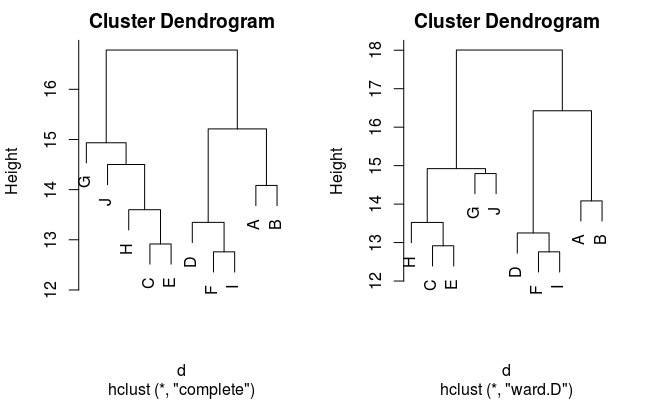

```r
clust.ward <- hclust(d,method = "ward.D")
par(mfrow=c(1,2))
plot(clust)
plot(clust.ward)
```

Exercise:

- Apply hierachical clustering to the Eucliden and Correlation distance matrices from the Colon Cancer data that you computed previously
- Do you see the same clustering arising from the different distance matrices?

```r
## Your answer here ##
```

The default plotting for a dendrogram labels the “leaves” with the column names from the input matrix, in our case the sample names from GEO. This may make the interpretation of the dendrogram difficult, as it may not be obvious which sample group each sample belongs to. We can alter the appearance of the dendrogram so that sample groups appear in the labels.

- Can use the `labels` argument to specify a vector that you want to use to label each leaf
  - the vector must be in the same order as the columns in the matrix that you did clustering on

```r
groups <- c(rep("Group1", 5),rep("Group2", 5))
groups
```

```
 [1] "Group1" "Group1" "Group1" "Group1" "Group1" "Group2" "Group2" "Group2" "Group2" "Group2"
```

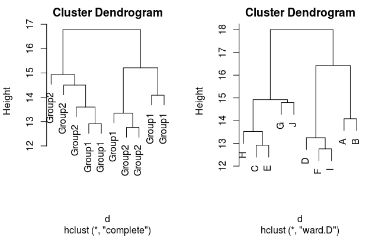

```r
par(mfrow=c(1,2))
plot(clust,labels=groups)
plot(clust.ward)
```

Exercise:

- Add text labels to indicate which sample group (tumour or normal) that each sample belongs to
  - below is a reminder of how to retrieve a matrix with all the sample metadata
  - does the clustering make sense in relation to the sample groups in the experiment?
  - do any samples appear incorrectly clustered?

```r
pd <- pData(colonData)
View(pd)
## Your answer here ##
```

The `WGCNA` package in Bioconductor provides methods for finding clusters of correlated genes, which we will not be looking at in this tutorial. However, the package is of interest as it provides other visualisation methods for dendrograms which allows colours to be overlaid to distinguish sample groups.

```r
library(WGCNA)
```

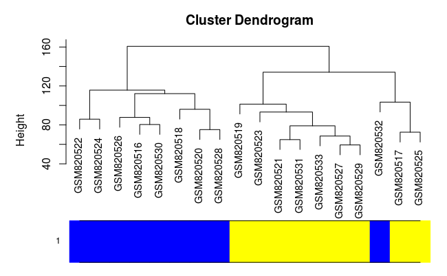

```r
clust.euclid = hclust(euc.dist)
clust.cor = hclust (cor.dist)
SampleGroup <- pData(colonData)$source_name_ch1
groupColours <- as.factor(SampleGroup)
levels(groupColours) <- c ("yellow" , "blue")
plotDendroAndColors(clust.euclid,colors=groupColours)
```

## Extracting data from the clustering

If we want to interpret the data presented in a clustering analysis, we need a way of extracting which samples are grouped together, or to determine the optimal grouping of samples.

- One intuitive way of assigning groups it to *cut* the dendrogram at a particular height on the y-axis.
- We can do this manually on the plot, or use the `cutree` function to return the labels of samples that are belong to the same group when the dendrogram is cut at the specified height, `h`.
- Alternatively, we can specify how many groups, `k`, that we want to create.

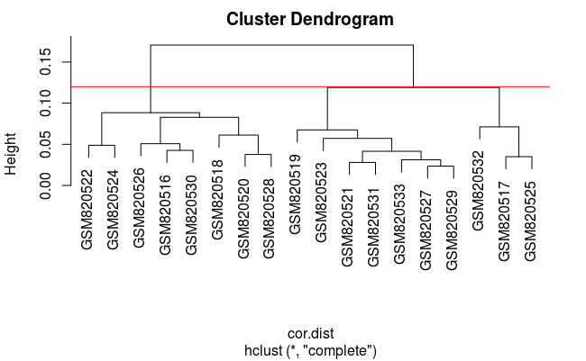

```r
library (cluster)
plot(clust.cor)
abline (h = 0.12, col = " red ")
```

```r
cutree (clust.cor , h = 0.12)
```

```
GSM820516 GSM820517 GSM820518 GSM820519 GSM820520 GSM820521 GSM820522 GSM820523 GSM820524 GSM820525 GSM820526 GSM820527 GSM820528 GSM820529 GSM820530
        1         2         1         2         1         2         1         2         1         2         1         2         1         2         1
GSM820531 GSM820532 GSM820533
        2         2         2
```

```r
cutree (clust.cor , k = 2)
```

```
GSM820516 GSM820517 GSM820518 GSM820519 GSM820520 GSM820521 GSM820522 GSM820523 GSM820524 GSM820525 GSM820526 GSM820527 GSM820528 GSM820529 GSM820530
        1         2         1         2         1         2         1         2         1         2         1         2         1         2         1
GSM820531 GSM820532 GSM820533
        2         2         2
```

```r
table (cutree(clust.cor , k = 3) , SampleGroup)
```

```
   SampleGroup
    normal tumor
  1      0     8
  2      2     1
  3      7     0
```

## Summary of clustering

- Useful as *exploratory / visualisation* tools
- Choice of metric, methods and parameters usually guided by prior knowledge about the question
  - The result is guided by what you are looking for
- Validate using different algorithms
- Use prior Biological knowledge, or your sample meta data to see if the clusters make sense
- Be aware
  - Clustering will always produce something. It cannot NOT work
- Clustering is a generic technique that can be applied to many forms of data
  - We will use it on Microarrays, but it can be used on RNA-seq, ChIP, or other NGS data
- Quality assessment of samples
  - checking for batch effects and outliers
  - check effectiveness of normalisation / transformation

## Producing a heatmap

A heatmap is often used to visualise differences between samples.

- Each row represents a gene and each column is an array and coloured cells indicate the expression levels of genes.
- Both samples and genes with similar expression profile are clustered together.
- The code to draw the heatmap is actually quite straighforward
  - the trick is to select what genes to use

Drawing a heatmap in R uses a lot of memory and can take a long time,

- Reducing the amount of data to be plotted is usually recommended.
- Including too many non-informative genes can also make it difficult to spot patterns.
- Typically, data are filtered to include the genes which tell us the most about the biological variation.
  - alternatively, use a pre-selected list of genes of interest
  - e.g. a particular pathway, or gene-list from another study
- In an un-supervised setting, the selection of such genes is done without using prior knowledge about the sample groupings.
- The `rowSds` function from `genefilter` provides a convenient way of calculating the variability of each gene

```r
geneVar = rowSds(exprs(colonData))
sd(exprs(colonData)[1,])
```

```
[1] 0.07726564
```

```r
geneVar[1]
```

```
ILMN_1343291
  0.07726564
```

```r
sd(exprs(colonData)[2,])
```

```
[1] 0.5612761
```

```r
geneVar[2]
```

```
ILMN_1343295
   0.5612761
```

```r
length(geneVar)
```

```
[1] 48803
```

Next we can select which genes have the highest variance (say the top 100+)

```r
highVarGenes = order (geneVar, decreasing = TRUE )[1:100]
```

- A basic heatmap can now be constructed by selecting the appropriate rows from the expression matrix
  - the `heatmap` function expects a `matrix` object, so we have to convert

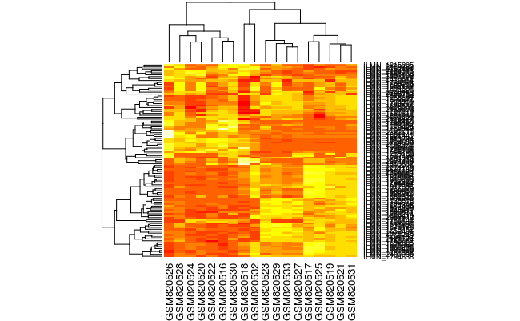

```r
heatmap (as.matrix(exprs(colonData)[highVarGenes, ]))
```

## Customising the heatmap

From this plot we can already to discern patterns in the data

- However, the rows are named according to the row names in the expression matrix
  - which in this case are manufacturer identifiers and do not help the interpretation
  - also, we have sample names without any information of the sample groupings.
- The column labels can be changed by specifying the `labCol` argument

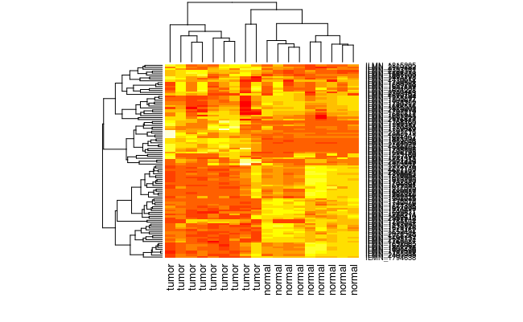

```r
heatmap (as.matrix(exprs(colonData)[highVarGenes, ]),
         labCol = SampleGroup)
```

In a similar way to adding colours to a dendrogram

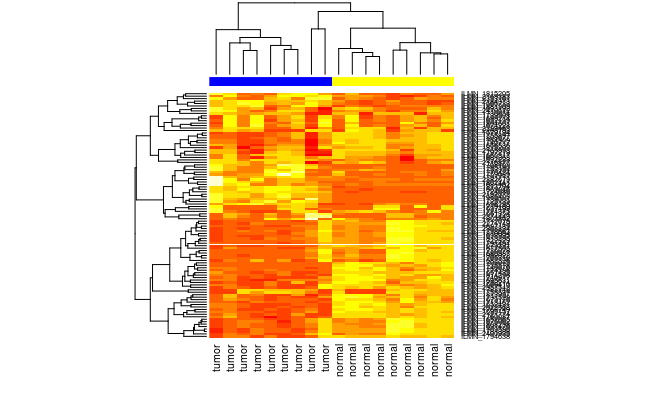

```r
sampleColours <- matrix(nrow=length(SampleGroup),ncol=1)
sampleColours[,1] <- as.character(groupColours)
heatmap (as.matrix(exprs(colonData)[highVarGenes, ]),
         labCol = SampleGroup,
         ColSideColors = sampleColours)
```

Exercise:

- How can we add gene names to the heatmap?
  - first out which column in the feature data corresponds to gene symbol
  - save this as a vector
  - find out which argument to heatmap you need to change

```r
features <- fData(colonData)
View(features)
## Your answer here ##
```

- The default options for the heatmap are to cluster both the genes (rows) and samples (columns).
- However, sometimes we might want to specify a particular order. For example, we might want to order the columns according to sample groups.
- We can do this by re-ordering the input matrix manually and setting the `Colv` argument to `NA`. This tells the heatmap function not be cluster the columns.

```r
heatmap (as.matrix(exprs(varFiltered)[highVarGenes, ]),
         labCol = SampleGroup , Colv=NA)
```

[output not shown]

Alternatively, a pre-calculated dendrogram could be used.

The colours used to display the gene expression values can also be modified. For this, we can use the `RColorBrewer` package which has functions for creating pre-defined palettes. The function `display.brewer.all` can be used to display the palettes available through this package.

**You should avoid using the traditional red / green colour scheme as it may be difficult for people with colour-blindness to interpret!**

## Other packages that produce heatmaps

One drawback of the standard `heatmap` function is that it only allows one “track” of colours below the dendrogram. We might wish to display various sample groupings using this feature. The `heatmap.plus` package allows us to do just this.

Another alternative is provided by the `gplots` package. The `heatmap.2` function can be used in the same fashion as `heatmap`. The plots produced include a colour legend for the cells in the heatmap. By default, a density plot of each column is also produced.

We can turn-off the column density if we wish.

# Principal Components Analysis

## Why Use PCA

- In genomic data, we have a large number of variables which are often highly correlated
- PCA is one of many *dimension-reduction* techniques that can remove redundancy and give a smaller more mangeable set of variables. In summary it can help us to:-
- Reduce *dimensionality* of the data
- Decrease the *redundancy* of the data
- Filter the *noise* in the data
- *Compress* the data

## PCA Example: Whisky

The data: 86 malt whiskies scored for 12 different taste categories

(https://www.mathstat.strath.ac.uk/outreach/nessie/nessie_whisky.html)

- Q. Can we find which whiskies have a similar taste profile?
- Q. What are the factors that determine the taste profile?

## What does PCA tell us for these data?

Allows us to visualise the dataset in two (perhaps three) dimensions and see the main sources of variation in the data

- in this case, which samples taste most similar

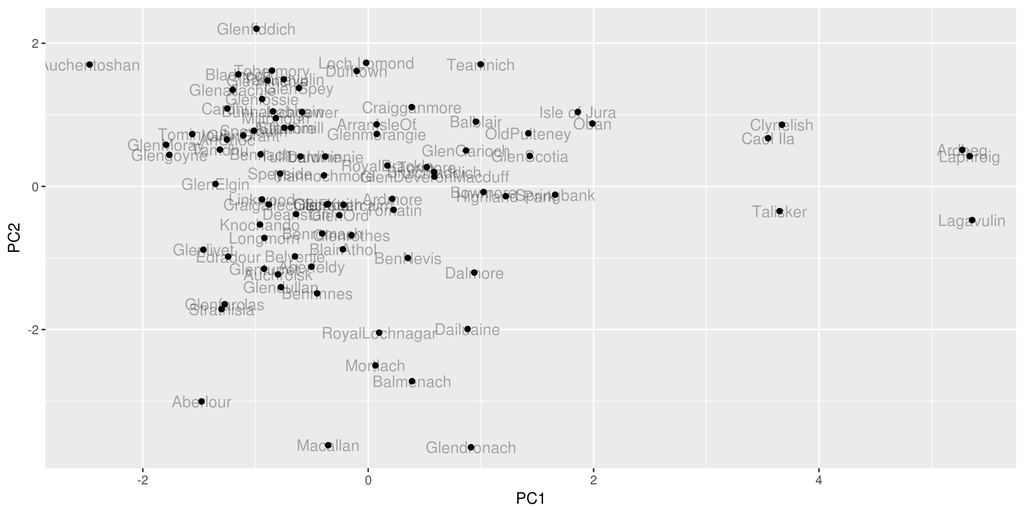

It is particularly useful to overlay known sample attributes to the plot

- can explain the similarities between whiskies

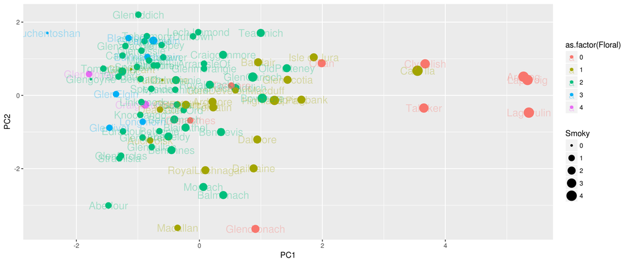

## More-relevant example

- MAQC microarrays with mixtures of Brain and Reference RNA (UHRR) at different concentrations
- Run in different labs
  - what do you notice?

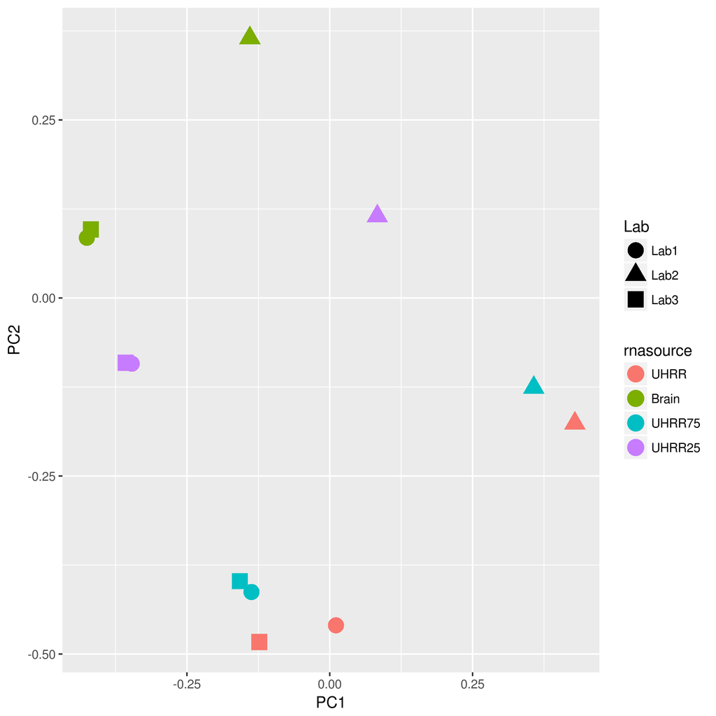

So, PCA can be used as a quality assessment tool and can inform us of any factors we need to account for in the analysis

- In this case we could correct for the batch effect, or add a batch factor to the linear model for analysis

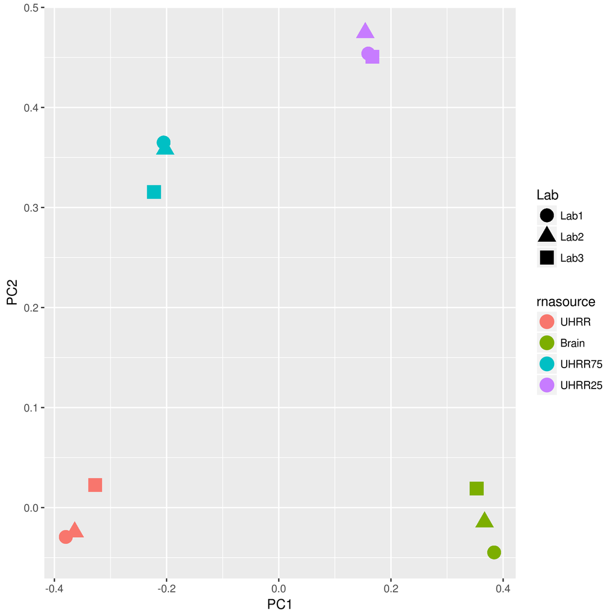

## What is going-on here?

A two-dimensional case

- Find direction of most variation (PC1)
- Direction that explains next amount of variation is orthogonal (at 90 degrees) (PC2)
- Each point on original x and y is a linear combination of PC1 and PC2
- Higher dimensional data can have many more components PC3, PC4….
  - although they will become increasingly less-influential

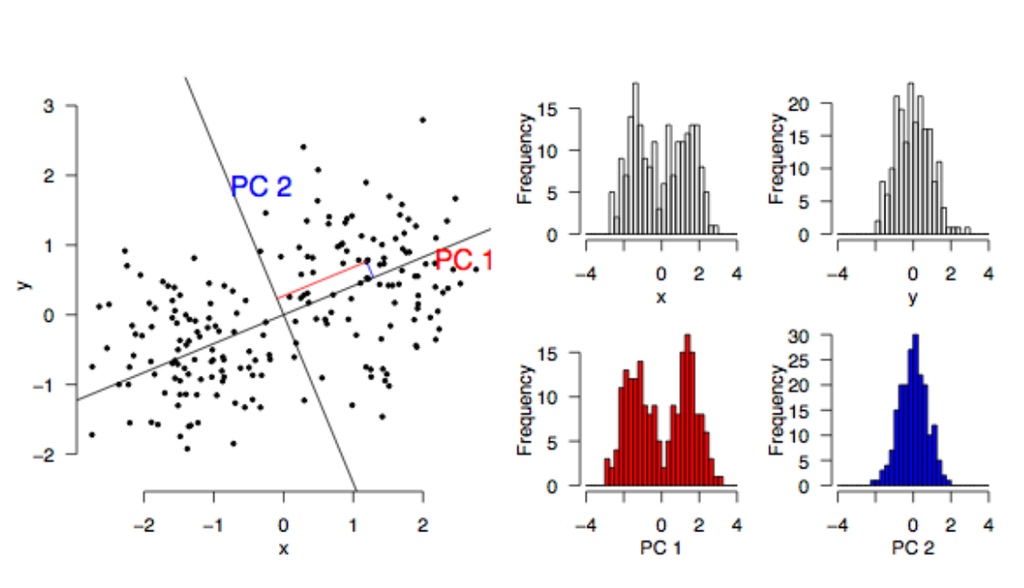

pca-explained

## Running the PCA

The `prcomp` function does the hard-work for us

## How many components?

We look at the variance explained by each component and judge where it “drops-off”

- Sometimes called a “scree-plot”

[figure not shown]

scree

The new co-ordinate system is given by `pca$x`

- One row for each of our whiskies, one column for each component
- The original coordinates are a linear combination of the new ones
  - an exercise for the reader?

Plotting the first and second columns as a scatter plot gives the plot we saw above

### Digression about ggplot2

The `ggplot2` package was actually used to create the plots.

- Beyond the scope of the course, but you should check out our [Intermediate R](http://bioinformatics-core-shared-training.github.io/r-intermediate/) course for more details
- Essentially, it allows us to map between the variables in our data and the characteristics of the plot
  - x- and y-axis position, colour, shape, size of points

## Applying PCA to gene expression data

In the above example, we had several whiskies and had made several observations about each

- Each row was a whisky, and the observations were in columns

In the gene expression case, we have biological samples and the measurements we have made are gene expression levels

- So for PCA we need to transpose the matrix
  - like we did prior to clustering
- We can then proceed as before

This time, the matrix `$rotation` has one row for each gene and one column for each component

- We are more interested in the new (projected) coordinates and how they relate to the (known) sample groups
  - remember these are found in `$x`

Quite often, we plot the first few PCs against each other to visualise sample relationship.

# Classification

The Bioconductor project has a collection of example datasets. Often these are used as examples to illustrate a particular package or functionality, or to accompany the analysis presented in a publication. For example, several datasets are presented to accompany the genefu package which has functions useful for the classification of breast cancer patients based on expression profiles. An experimental dataset can be installed and loaded as with any other Bioconductor package. The data itself is saved as an object in the package. You will need to see the documentation for the package to find out the relevant object name. The full list of datasets available through Bioconductor can be found [here](http://bioconductor.org/packages/release/BiocViews.html#___ExperimentData)

```r
library(breastCancerVDX)
library(breastCancerTRANSBIG)
data(vdx)
data(transbig)
dim(vdx)
```

```
Features  Samples
   22283      344
```

```r
dim(transbig)
```

```
Features  Samples
   22283      198
```

```r
annotation(vdx)
```

```
[1] "hgu133a"
```

```r
annotation(transbig)
```

```
[1] "hgu133a"
```

If we want any classifers to be reproducible and applicable to other datasets, it is sensible to exclude probes that do not have sufficient annotation from the analysis. For this, we can use the genefilter package as before. The nsFilter function performs this annotation-based filtering as well as variance filtering. The output of the function includes details about how many probes were removed at each stage of the filtering.

```r
library (genefilter)
vdx.filt <- nsFilter(vdx)
vdx.filt
```

```
$eset
ExpressionSet (storageMode: lockedEnvironment)
assayData: 6218 features, 344 samples
  element names: exprs
protocolData: none
phenoData
  sampleNames: VDX_3 VDX_5 ... VDX_2038 (344 total)
  varLabels: samplename dataset ... e.os (21 total)
  varMetadata: labelDescription
featureData
  featureNames: 206797_at 203440_at ... 201130_s_at (6218 total)
  fvarLabels: probe Gene.title ... GO.Component.1 (22 total)
  fvarMetadata: labelDescription
experimentData: use 'experimentData(object)'
  pubMedIds: 17420468
Annotation: hgu133a

$filter.log
$filter.log$numDupsRemoved
[1] 7408

$filter.log$numLowVar
[1] 6219

$filter.log$numRemoved.ENTREZID
[1] 2428

$filter.log$feature.exclude
[1] 10
```

```r
vdx.filt <- vdx.filt[[1]]
```

Format the vdx data for pamr, and train a classifier to predict ER status. For extra clarity in the results, it might be useful to rename the binary er status used in the data package to something more descriptive.

Fitting the model

There are a couple of ways of extract the details of the genes that have been used in the classifier. We can list their names using the pamr.listgenes function, which in our case these are just returns the microarray probe names. We can however, use these IDs to query the `featureData` stored with the original `vdx` object. We can also plot the expression values for each gene, coloured according to the class label.

Use the genes identified by the classifier to produce a heatmap to confirm that they separate the samples as expected.

## Testing the model

We can now test the classifier on an external dataset. We choose the transbig dataset for simplicity as it was generated on the same microarray platform

Make a heatmap of the transbig data using the genes involved in the vxd classifier

# Survival Analysis